# Motivation

## Importing external simulations (e.g. from Bayesian software or unsupported packages)

As mentioned earlier, the quantile residuals defined in DHARMa are the frequentist equivalent of the so-called “Bayesian p-values”, i.e. residuals created from posterior predictive simulations in a Bayesian analysis.

To make the plots and tests in DHARMa also available for Bayesian analysis, DHARMa provides the option to convert externally created posterior predictive simulations into a DHARMa object

```r
res = createDHARMa(scaledResiduals = posteriorPredictiveSimulations, simulatedResponse = medianPosteriorPredictions, observedResponse = observations, integerResponse = ?)
```

What is provided as simulatedResponse is up to the user, but median posterior predictions seem most sensible to me. After the conversion, all DHARMa plots can be used, however, note that Bayesian p-values != DHARMA residuals, because in the Bayesian analysis, parameters are varied as well.

**Important**: as DHARMa doesn't know the distribution fitted model, it is vital to specify the integerResponse option by hand (see above / ?simulateResiduals for details).

# Case studies and examples

**Note:** More real-world examples on the DHARMa GitHub repository [here](https://github.com/florianhartig/DHARMa/tree/master/Code/Examples)

## Budworm example (count-proportion n/k binomial)

This example comes from [Jochen Fründ](https://jochenfruend.wordpress.com/). Measured are the number of parasitized observations, with population density as a covariate

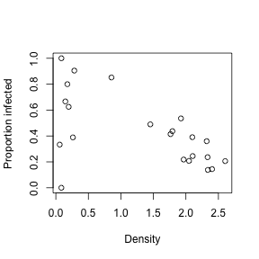

```r
plot(N_parasitized / (N_adult + N_parasitized ) ~ logDensity, xlab = "Density", ylab = "Proportion infected", data = data)
```

Let's fit the data with a regular binomial n/k glm

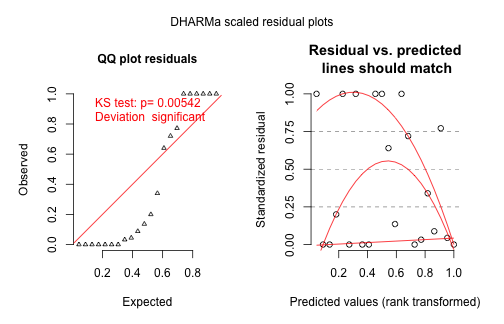

```r
mod1 <- glm(cbind(N_parasitized, N_adult) ~ logDensity, data = data, family=binomial)
simulationOutput <- simulateResiduals(fittedModel = mod1)
plot(simulationOutput)
```

The residuals look clearly overdispersed. We can confirm that with the omnibus test

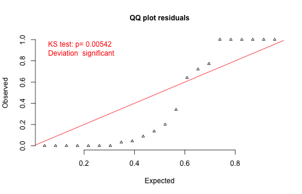

```
##
##  One-sample Kolmogorov-Smirnov test
##
## data:  simulationOutput$scaledResiduals
## D = 0.36655, p-value = 0.005415
## alternative hypothesis: two-sided
```

```r
testUniformity(simulationOutput = simulationOutput)
```

Or with the more powerful overdispersion test

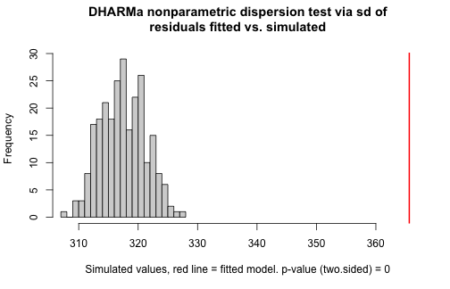

```
##
##  DHARMa nonparametric dispersion test via sd of residuals fitted
##  vs. simulated
##
## data:  simulationOutput
## ratioObsSim = 1.1516, p-value < 2.2e-16
## alternative hypothesis: two.sided
```

```r
testOverdispersion(simulationOutput = simulationOutput)
```

OK, so let's add overdispersion through an individual-level random effect

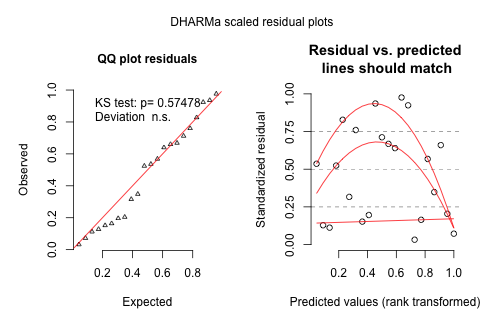

```r
mod2 <- glmer(cbind(N_parasitized, N_adult) ~ logDensity + (1|ID), data = data, family=binomial)
simulationOutput <- simulateResiduals(fittedModel = mod2)
plot(simulationOutput)
```

The overdispersion looks better, but you can see that the residuals look a bit irregular.

Likely, the reason is the steep increase in the beginning that one can see in the raw data plot. One would probably need to apply another transformation or a nonlinear function to completely fit this away.

## Beetlecount / Poisson example

#### Dataset

This example is a synthetic dataset of measured beetle counts over 50 plots across an altitudinal gradient that are yearly sampled over 20 years. The following plot shows the observed number of beetles (log10) vs. altitude. Additional variables in the data are soil moisture and the amount of deadwood on the plots.

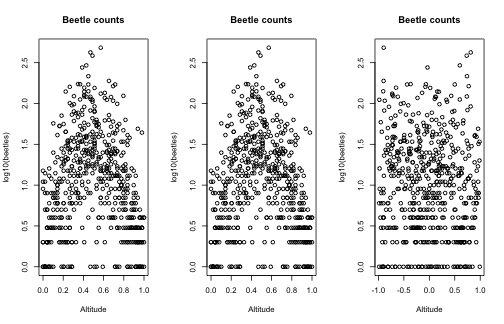

```r
par(mfrow = c(1,3))
plot(log10(beetles) ~ altitude + I(altitude) + moisture, data = data, main = "Beetle counts", xlab = "Altitude")
```

Our question is: what is the effect of altitude on the abundance of the beetle? Let's start with a linear and quadratic term for altitude, linear effect of soil moisture, and random intercepts on plot and year

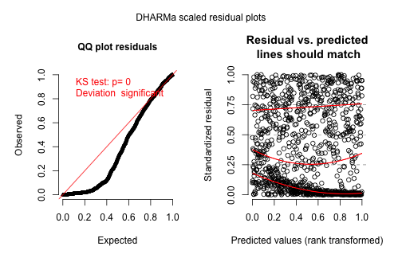

```r
mod <- glmer(beetles ~ altitude + I(altitude^2) + moisture + (1|plot) + (1|year), data = data, family=poisson, control = glmerControl(optCtrl = list(maxfun = 10000)))
simulationOutput <- simulateResiduals(fittedModel = mod)
plot(simulationOutput)
```

```r
summary(mod)
```

```
## Generalized linear mixed model fit by maximum likelihood (Laplace
##   Approximation) [glmerMod]
##  Family: poisson  ( log )
## Formula: beetles ~ altitude + I(altitude^2) + moisture + (1 | plot) +
##     (1 | year)
##    Data: data
## Control: glmerControl(optCtrl = list(maxfun = 10000))
##
##      AIC      BIC   logLik deviance df.resid
##  20493.9  20523.4 -10241.0  20481.9      994
##
## Scaled residuals:
##      Min       1Q   Median       3Q      Max
## -12.4093  -2.1837  -0.7425   1.8807  21.6505
##
## Random effects:
##  Groups Name        Variance Std.Dev.
##  plot   (Intercept) 0.1906   0.4366
##  year   (Intercept) 1.0850   1.0416
## Number of obs: 1000, groups:  plot, 50; year, 20
##
## Fixed effects:
##               Estimate Std. Error z value Pr(>|z|)
## (Intercept)    -0.1998     0.2987  -0.669    0.504
## altitude       12.2749     0.8595  14.282   <2e-16 ***
## I(altitude^2) -12.5505     0.8337 -15.054   <2e-16 ***
## moisture       -0.2125     0.0161 -13.196   <2e-16 ***
## ---
## Signif. codes:  0 '***' 0.001 '**' 0.01 '*' 0.05 '.' 0.1 ' ' 1
##
## Correlation of Fixed Effects:
##             (Intr) altitd I(l^2)
## altitude    -0.539
## I(altitd^2)  0.461 -0.967
## moisture     0.008 -0.006  0.006
```

We see that we have a problem when we plot residuals against deadwood

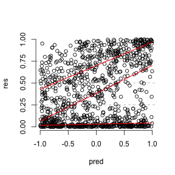

```r
plotResiduals(data$deadwood, simulationOutput$scaledResiduals)
```

so let's add this term as well

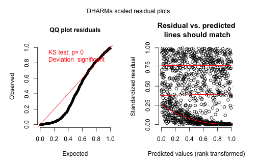

```r
mod <- glmer(beetles ~ altitude + I(altitude^2) + moisture + deadwood + (1|plot) + (1|year) , data = data, family=poisson, control = glmerControl(optCtrl = list(maxfun = 10000)))
simulationOutput <- simulateResiduals(fittedModel = mod)
plot(simulationOutput)
```

```r
summary(mod)
```

```
## Generalized linear mixed model fit by maximum likelihood (Laplace
##   Approximation) [glmerMod]
##  Family: poisson  ( log )
## Formula: beetles ~ altitude + I(altitude^2) + moisture + deadwood + (1 |
##     plot) + (1 | year)
##    Data: data
## Control: glmerControl(optCtrl = list(maxfun = 10000))
##
##      AIC      BIC   logLik deviance df.resid
##  15162.1  15196.4  -7574.0  15148.1      993
##
## Scaled residuals:
##      Min       1Q   Median       3Q      Max
## -11.3157  -1.6833  -0.0885   1.9843  14.3762
##
## Random effects:
##  Groups Name        Variance Std.Dev.
##  plot   (Intercept) 0.1778   0.4217
##  year   (Intercept) 1.1115   1.0543
## Number of obs: 1000, groups:  plot, 50; year, 20
##
## Fixed effects:
##                Estimate Std. Error z value Pr(>|z|)
## (Intercept)    -0.47665    0.29746   -1.60    0.109
## altitude       12.42714    0.83225   14.93   <2e-16 ***
## I(altitude^2) -12.57408    0.80740  -15.57   <2e-16 ***
## moisture       -0.27695    0.01638  -16.91   <2e-16 ***
## deadwood        1.18974    0.01715   69.38   <2e-16 ***
## ---
## Signif. codes:  0 '***' 0.001 '**' 0.01 '*' 0.05 '.' 0.1 ' ' 1
##
## Correlation of Fixed Effects:
##             (Intr) altitd I(l^2) moistr
## altitude    -0.525
## I(altitd^2)  0.449 -0.967
## moisture     0.010 -0.007  0.006
## deadwood    -0.023  0.003 -0.002 -0.055
```

still, there is obviously overdispersion in the data, so we'll add an individual level random effect to account for overdispersion

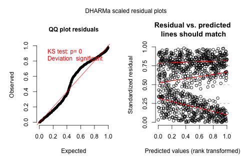

```r
mod <- glmer(beetles ~ altitude + I(altitude^2) + moisture + deadwood + (1|plot) + (1|year) + (1|dataID) , data = data, family=poisson, control = glmerControl(optCtrl = list(maxfun = 10000)))
simulationOutput <- simulateResiduals(fittedModel = mod)
plot(simulationOutput)
```

The data still looks overdispersed. The reason is that there is in fact no standard overdispersion, but zero-inflation in the data. We can look at the excess zeros via

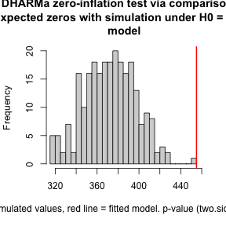

```
##
##  DHARMa zero-inflation test via comparison to expected zeros with
##  simulation under H0 = fitted model
##
## data:  simulationOutput
## ratioObsSim = 1.2203, p-value < 2.2e-16
## alternative hypothesis: two.sided
```

```r
testZeroInflation(simulationOutput)
```

which shows that we have too many zeros. We need a GLMM with zero-inflation. The easiest option is to do this in a Bayesian framework, e.g. in JAGS as in [this example](https://github.com/florianhartig/LearningBayes/blob/master/CommentedCode/04-StandardModels/GLMM/Beetles.md)

To be honest, however, if I hadn’t created the data with zero-inflation myself, I would be hard pressed to say with certainty that zero-inflation is the cause of these residual patterns. The reason is that, if a model is presented with zero-inflated data, the mean model predictions will be drawn towards the zeros, which in turn means that mean model-predictions underestimate the “normal” data. Hence zero-inflation often looks like overdispersion, and seeing such a pattern after accounting for overdispersion might as well mean that the distributional assumptions of the chosen model are not fulfilled (for example because overdispersion is more heavy-tailed than in the chose distribution). The best way to test if the problem is really due to zero-inflation is probably to run model selections (e.g. simulated LRTs) between a number of alternative models, e.g. a zero-inflated GLMM vs. a number of different overdispersed GLMMs.

## Binomial 0/1 data

There are a lot of rumors about that can and cannot be checked with binomial 0/1 data. Let's consider a clearly misspecified binomial model

```r
testData = createData(sampleSize = 500, overdispersion = 0, fixedEffects = 5, family = binomial(), randomEffectVariance = 3, numGroups = 25)
fittedModel <- glm(observedResponse ~ 1, family = "binomial", data = testData)

simulationOutput <- simulateResiduals(fittedModel = fittedModel)
```

A rumor that is true is that, unlike in k/n or count data, such a misspecification will not produce overdispersion.

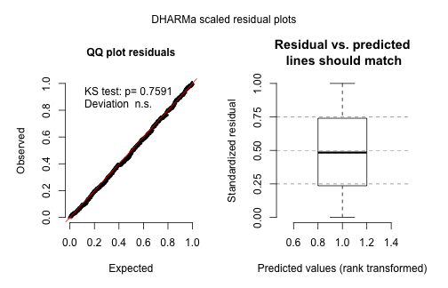

```r
plot(simulationOutput, asFactor = T)
```

However, you can clearly see the misfit if you plot

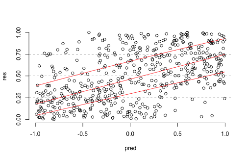

```r
plotResiduals(testData$Environment1, simulationOutput$scaledResiduals, quantreg = T)
```

Moreover, if you perform the DHARMa procedure per group, you can see overdispersion created by the random effect variance (left without grouping, right with grouping)

```r
par(mfrow = c(1,2))
testDispersion(simulationOutput)
```

```
##
##  DHARMa nonparametric dispersion test via sd of residuals fitted
##  vs. simulated
##
## data:  simulationOutput
## ratioObsSim = 1.0012, p-value = 1
## alternative hypothesis: two.sided
```

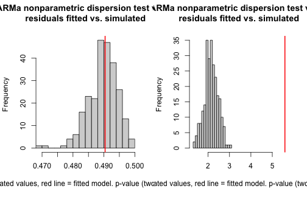

```
##
##  DHARMa nonparametric dispersion test via sd of residuals fitted
##  vs. simulated
##
## data:  simulationOutput
## ratioObsSim = 2.6099, p-value < 2.2e-16
## alternative hypothesis: two.sided
```

```r
simulationOutput = recalculateResiduals(simulationOutput , group = testData$group)
testDispersion(simulationOutput)
```